# Marketing Campaigns of Portuguese Bank

## 1.1 Insights about the data

With the obtained knowledge of the distribution of the variables, we can perform further analysis for each customer characteristics in order to investigate its influence on the subscription rate, i.e. on the rate of subscriptions to the term deposit.

Let’s better visualize the scatter plot of the 2 variables ‘campaign’ and ‘duration’, encoding the target class in the plot:

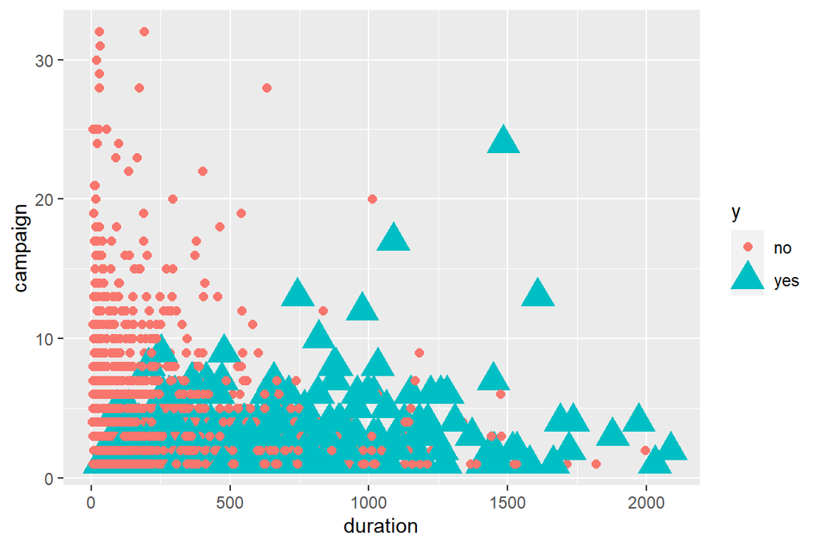

```r
ggplot(data, aes(x=duration, y=campaign, shape=y, color=y, size=y)) +
  geom_point()
```

As shown in the above plot, ‘duration’ and ‘campaign’ variables allow to create approximately 2 clusters of customers:

- almost all the ‘yes’ clients are characterized by low value of ‘campaign’ and they may have also high ‘duration’.
- ‘no’ clients have higher values on campaign and low ‘duration’ values.

An important observation is that an high value of the ‘campaign’ variable makes the clients to refuse to sign for the term deposit: almost all observations with ‘campaign’ value above 10 have ‘no’ as target variable value.

It may be useful to better visualize the scatter plot of the 2 variables ‘age’ and ‘contact’, because it is more probable that older people are more used to be contacted by telephone rather than cellular:

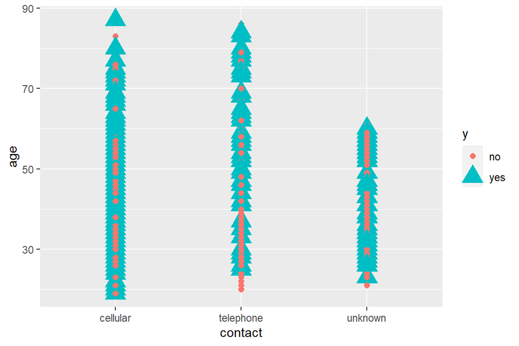

```r
ggplot(data, aes(x=contact, y=age, shape=y, color=y, size=y)) +
  geom_point()
```

It seems the there is no relationship between ‘contact’ and ‘age’.

Another possible observation could be extracted from the scatter plot of the 2 variables ‘age’ and ‘balance’:

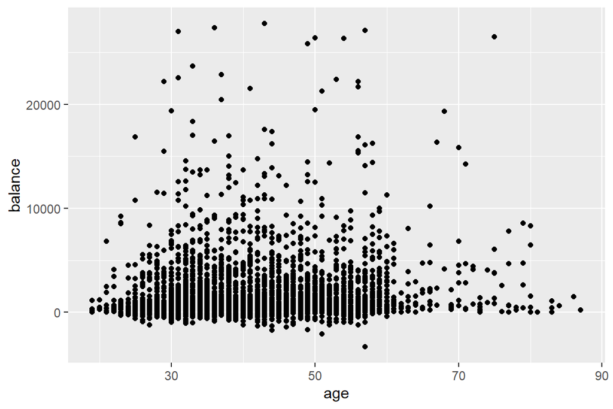

```r
ggplot(data, aes(x=age, y=balance)) +
  geom_point()
```

The above scatter plot doesn’t show any strong relationship among the 2 variables: most of the customers contacted by the bank has low salary, independently from the age.

We can now represent the correlation matrix among these quantitative variables:

```r
# compute correlation matrix
res <- cor(data[, cols])
round(res, 2)
```

```
##            age balance   day duration campaign pdays previous
## age       1.00    0.08 -0.02    -0.01    -0.01 -0.01     0.00
## balance   0.08    1.00  0.00    -0.02     0.00  0.01     0.03
## day      -0.02    0.00  1.00    -0.03     0.16 -0.09    -0.06
## duration -0.01   -0.02 -0.03     1.00    -0.07  0.01     0.02
## campaign -0.01    0.00  0.16    -0.07     1.00 -0.10    -0.07
## pdays    -0.01    0.01 -0.09     0.01    -0.10  1.00     0.58
## previous  0.00    0.03 -0.06     0.02    -0.07  0.58     1.00
```

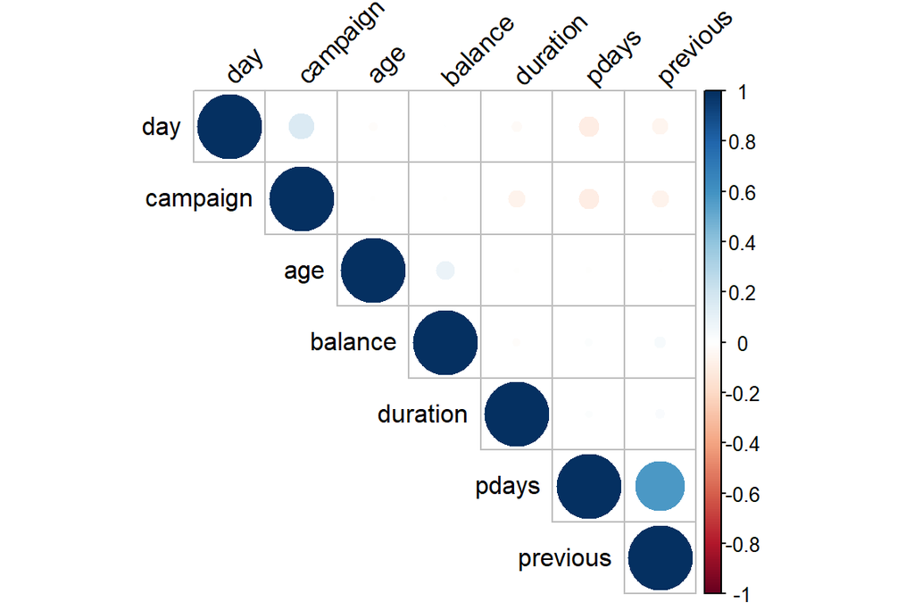

```r
library(corrplot)
corrplot(res, type = "upper", order = "hclust",
         tl.col = "black", tl.srt = 45)
```

### 1.1.1 Subscription rate per age

```r
data2 = data

data2$age = cut(data2$age, breaks = c(0, 29, 39, 49, 59, 69, 100),
                 labels = c('<30','30-39','40-49',
                            '50-59','60-69','70+'
                            ))
```

```r
data$age[16]
```

```
## [1] 40
```

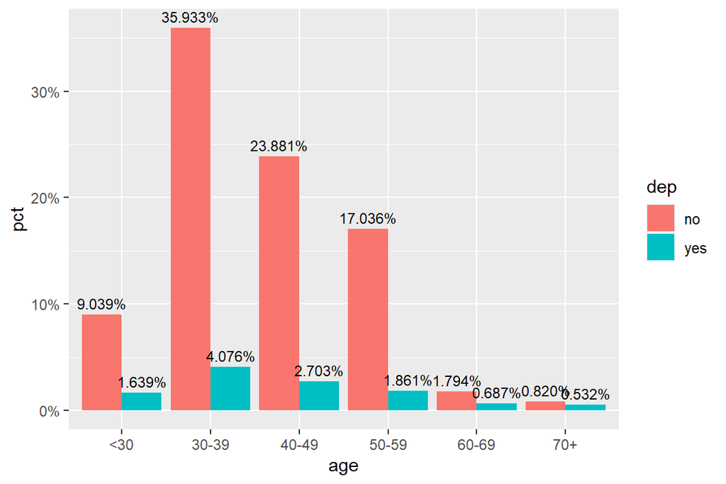

```r
data2 %>%
    count(age = factor(age), dep = factor(y)) %>%
    mutate(pct = prop.table(n)) %>%
    ggplot(aes(x = age, y = pct, fill = dep, label = scales::percent(pct))) +
    geom_col(position = 'dodge') +
    geom_text(position = position_dodge(width = .9),    # move to center of bars
              vjust = -0.5,    # nudge above top of bar
              size = 3) +
    scale_y_continuous(labels = scales::percent)
```

The above plot suggests that:

- clients with a age above 60 have the highest subscription rate: since the percentage of ‘yes’ is very close to the one of ‘no’, meaning that a lot of the people contacted by the bank signed for the term deposit.
- it is not surprising to see such a pattern because the main investment objective of older people is saving for retirement while the middle-aged group tend to be more aggressive with a main objective of generating high investment income. Term deposits, as the least risky investment tool, are more preferable to the eldest.
- The youngest may not have enough money or professional knowledge to engage in sophisticated investments, such as stocks and mutual funds. Term deposits provide liquidity and generate interest incomes that are higher than the regular saving account, so term deposits are ideal investments for students.

We could better visualize this characteristics by taking into account only customers that signed a term deposit:

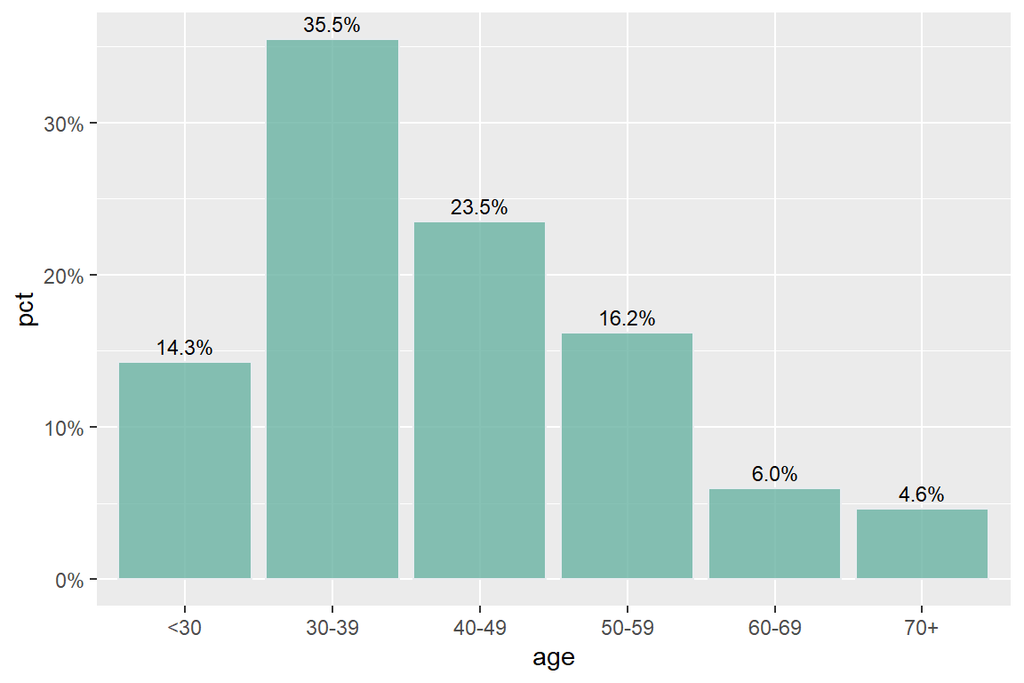

```r
data_yes <- data2[which(data2$y == 'yes'), ]  # all yes's of target class

data_yes %>%
    count(age = factor(age), dep = factor(y)) %>%
    mutate(pct = prop.table(n)) %>%
    ggplot(aes(x = age, y = pct, label = scales::percent(pct))) +
    geom_col(position = 'dodge', fill="#69b3a2", color="#e9ecef", alpha=0.8) +
    geom_text(position = position_dodge(width = .9),    # move to center of bars
              vjust = -0.5,    # nudge above top of bar
              size = 3) +
    scale_y_continuous(labels = scales::percent)
```

The plot clearly shows that the age range of people most contacted by the bank is the one between 30 and 60, this explains the high percentage of subscriptions. But this may be misleading, as we saw above that older people are much more likely to sign.

### 1.1.2 Subscription rate per job

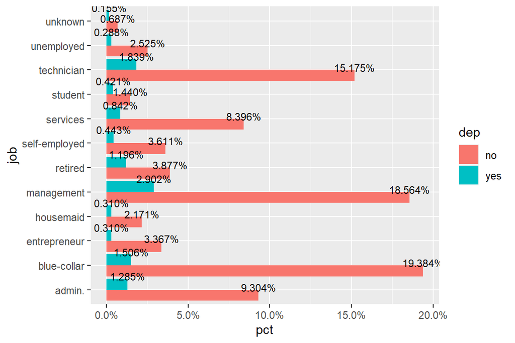

```r
data %>%
    count(job = factor(job), dep = factor(y)) %>%
    mutate(pct = prop.table(n)) %>%
    ggplot(aes(x = job, y = pct, fill = dep, label = scales::percent(pct))) +
    geom_col(position = 'dodge') +
    geom_text(position = position_dodge(width = .9),    # move to center of bars
              vjust = -0.5,    # nudge above top of bar
              size = 3) +
    scale_y_continuous(labels = scales::percent)+
    theme_grey()+
    coord_flip()
```

The plot above allows to draw other interesting conclusions, also related to what we saw before:

- the percentage of ‘yes’ is very high for ‘retired’ and ‘student’ categories, as we already found out above when studying the age ranges.

### 1.1.3 Subscription rate by balance level

In order to better understand the effect of the balance on the probability to sign for a term contract, we can visualize it by means of an histogram:

```r
# cut balances into
data2 <- data
data2$balance = cut(data2$balance, breaks = c(-5000, -1,  2000, 5000, 10000, 15000, 30000),
                 labels = c('<0', '0-2000', '2000-5000','50000-10000', '10000-15000', '>150000'
                            ))
```

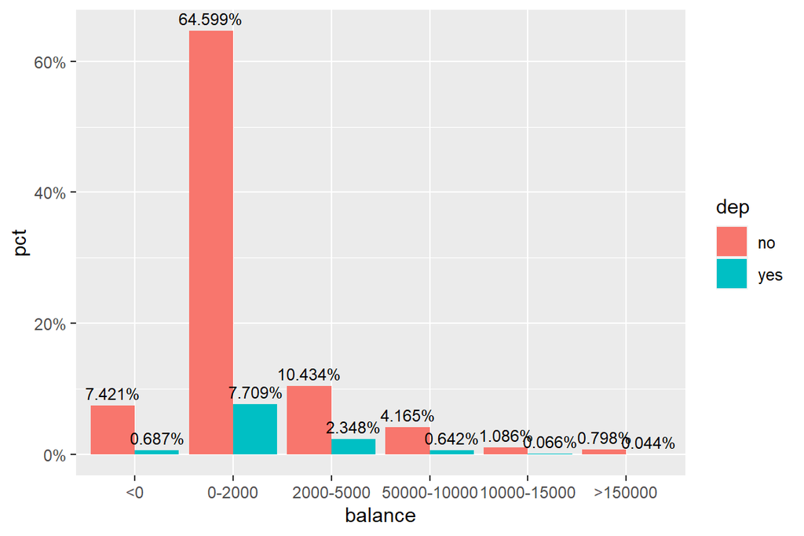

```r
data2 %>%
    count(balance = factor(balance), dep = factor(y)) %>%
    mutate(pct = prop.table(n)) %>%
    ggplot(aes(x = balance, y = pct, fill = dep, label = scales::percent(pct))) +
    geom_col(position = 'dodge') +
    geom_text(position = position_dodge(width = .9),    # move to center of bars
              vjust = -0.5,    # nudge above top of bar
              size = 3) +
    scale_y_continuous(labels = scales::percent)
```

Observations:

- Clients with a balance in the range 2000-5000 are the ones with a highest subscription rate

In order to confirm our hypotheses, we can combine together the information from the ages with that of the balances:

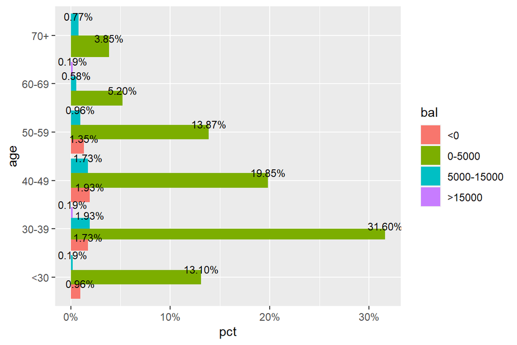

```r
data2 <- data
data2$balance = cut(data2$balance, breaks = c(-5000, -1,  5000, 15000, 30000),
                 labels = c('<0', '0-5000', '5000-15000','>15000'
                            ))
data2$age = cut(data2$age, breaks = c(0, 29, 39, 49, 59, 69, 100),
                 labels = c('<30','30-39','40-49',
                            '50-59','60-69','70+'
                            ))
data_yes <- data2[which(data2$y == 'yes'), ]  # all yes's of target class
data_yes %>%
    count(age = factor(age), bal = factor(balance)) %>%
    mutate(pct = prop.table(n)) %>%
    ggplot(aes(x = age, y = pct, fill = bal, label = scales::percent(pct))) +
    geom_col(position = 'dodge') +
    geom_text(position = position_dodge(width = .9),    # move to center of bars
              vjust = -0.5,    # nudge above top of bar
              size = 3) +
    scale_y_continuous(labels = scales::percent)+
    coord_flip()
```

We can see that the highest number of ‘yes’ is in the age range ‘30-39’ for clients with a balance between ‘0-5000’, since they represent the most called people by the bank.

## 1.2 Preparing the dataset

We’ll now prepare the dataset for the classification task. We remind that our goal is to use the customers characteristics to predict whether they will sign for a term deposit. This will allow the bank to identify the customers to contact in future marketing campaigns.

### 1.2.1 Feature engineering

We think that the variables ‘contact’ and ‘day’ are not very useful for the classification task:

- for what regards the ‘day’ variable, we have seen in the previous plots how it’s density is pretty uniform along the days of the month, therefore we’ll not consider this variable for performing the classification algorithms.
- the variable ‘contact’ indicates the type of mean used to contact the customers: the above plots show that it is not an interesting feature for the classification task.

```r
drop = c("contact", "day")
data = data[,!(names(data) %in% drop)]
```

```r
str(data)
```

```
## 'data.frame':    4514 obs. of  16 variables:
##  $ ID       : int  1 2 3 4 5 6 7 8 9 10 ...
##  $ age      : int  30 33 35 30 59 35 36 39 41 43 ...
##  $ job      : Factor w/ 12 levels "admin.","blue-collar",..: 11 8 5 5 2 5 7 10 3 8 ...
##  $ marital  : Factor w/ 3 levels "divorced","married",..: 2 2 3 2 2 3 2 2 2 2 ...
##  $ education: Factor w/ 4 levels "primary","secondary",..: 1 2 3 3 2 3 3 2 3 1 ...
##  $ default  : Factor w/ 2 levels "no","yes": 1 1 1 1 1 1 1 1 1 1 ...
##  $ balance  : int  1787 4789 1350 1476 0 747 307 147 221 -88 ...
##  $ housing  : Factor w/ 2 levels "no","yes": 1 2 2 2 2 1 2 2 2 2 ...
##  $ loan     : Factor w/ 2 levels "no","yes": 1 2 1 2 1 1 1 1 1 2 ...
##  $ month    : Factor w/ 12 levels "apr","aug","dec",..: 11 9 1 7 9 4 9 9 9 1 ...
##  $ duration : int  79 220 185 199 226 141 341 151 57 313 ...
##  $ campaign : int  1 1 1 4 1 2 1 2 2 1 ...
##  $ pdays    : int  -1 339 330 -1 -1 176 330 -1 -1 147 ...
##  $ previous : int  0 4 1 0 0 3 2 0 0 2 ...
##  $ poutcome : Factor w/ 4 levels "failure","other",..: 4 1 1 4 4 1 4 4 4 1 ...
##  $ y        : Factor w/ 2 levels "no","yes": 1 1 1 1 1 1 1 1 1 1 ...
```

Since the variable ‘pdays’ is very spread in the past and has a lot of ‘-1’ values (which makes the classification task harder compromising the training), we decided to group values into 7 bins:

```r
data$pdays = cut(data$pdays, breaks = c(-2,-1,90,181,272,363,545,max(data$pdays)+1),
                 labels = c('Never contacted','Under 3months','Under 6months',
                            'Under 9months','Under 1yr','Under 1.5yrs',
                            'Over 1.5yrs'))
summary(data$pdays)
```

```
## Never contacted   Under 3months   Under 6months   Under 9months       Under 1yr
##            3698              71             269             189             209
##    Under 1.5yrs     Over 1.5yrs
##              71               7
```

```r
save(data, file="preprocessed_data.RData")
```

### 1.2.2 Convert categorical variables

Since most classification algorithms work with continuous variables, we need to one-hot encode categorial variables. In order to do that, we’ll convert all the categorical variables into ‘dummy’ variables, i.e. we represent a categorical variable as a numerical variable for each category that takes on one of two values: zero or one.

We’ll use the *dummyCols* function of the *fastDummes* package of R:

Let’s see how it works for a single variable (‘poutcome’):

```r
#install.packages('fastDummies')
library('fastDummies')
# Create dummy variables:
data_dummy <- dummy_cols(data, select_columns = 'poutcome', remove_selected_columns = TRUE)
```

```r
head(data_dummy)
```

| ID | age | job | marital | education | default | balance | housing | loan | month | duration | campaign | pdays | previous | y | poutcome_failure | poutcome_other | poutcome_success | poutcome_unknown |
| --- | --- | --- | --- | --- | --- | --- | --- | --- | --- | --- | --- | --- | --- | --- | --- | --- | --- | --- |
| 1 | 30 | unemployed | married | primary | no | 1787 | no | no | oct | 79 | 1 | Never contacted | 0 | no | 0 | 0 | 0 | 1 |
| 2 | 33 | services | married | secondary | no | 4789 | yes | yes | may | 220 | 1 | Under 1yr | 4 | no | 1 | 0 | 0 | 0 |
| 3 | 35 | management | single | tertiary | no | 1350 | yes | no | apr | 185 | 1 | Under 1yr | 1 | no | 1 | 0 | 0 | 0 |
| 4 | 30 | management | married | tertiary | no | 1476 | yes | yes | jun | 199 | 4 | Never contacted | 0 | no | 0 | 0 | 0 | 1 |
| 5 | 59 | blue-collar | married | secondary | no | 0 | yes | no | may | 226 | 1 | Never contacted | 0 | no | 0 | 0 | 0 | 1 |
| 6 | 35 | management | single | tertiary | no | 747 | no | no | feb | 141 | 2 | Under 6months | 3 | no | 1 | 0 | 0 | 0 |

```r
summary(data_dummy)
```

```
##        ID            age                 job          marital
##  Min.   :   1   Min.   :19.00   management :969   divorced: 527
##  1st Qu.:1130   1st Qu.:33.00   blue-collar:943   married :2791
##  Median :2258   Median :39.00   technician :768   single  :1196
##  Mean   :2260   Mean   :41.16   admin.     :478
##  3rd Qu.:3389   3rd Qu.:49.00   services   :417
##  Max.   :4521   Max.   :87.00   retired    :229
##                                 (Other)    :710
##      education    default       balance        housing     loan
##  primary  : 674   no :4438   Min.   :-3313.0   no :1958   no :3824
##  secondary:2305   yes:  76   1st Qu.:   69.0   yes:2556   yes: 690
##  tertiary :1348              Median :  444.5
##  unknown  : 187              Mean   : 1398.9
##                              3rd Qu.: 1477.0
##                              Max.   :27733.0
##
##      month         duration         campaign                  pdays
##  may    :1398   Min.   :   4.0   Min.   : 1.000   Never contacted:3698
##  jul    : 704   1st Qu.: 104.0   1st Qu.: 1.000   Under 3months  :  71
##  aug    : 632   Median : 185.0   Median : 2.000   Under 6months  : 269
##  jun    : 529   Mean   : 262.4   Mean   : 2.775   Under 9months  : 189
##  nov    : 389   3rd Qu.: 329.0   3rd Qu.: 3.000   Under 1yr      : 209
##  apr    : 293   Max.   :2087.0   Max.   :32.000   Under 1.5yrs   :  71
##  (Other): 569                                     Over 1.5yrs    :   7
##     previous         y        poutcome_failure poutcome_other poutcome_success
##  Min.   : 0.0000   no :3995   Min.   :0.0000   Min.   :0      Min.   :0.00000
##  1st Qu.: 0.0000   yes: 519   1st Qu.:0.0000   1st Qu.:0      1st Qu.:0.00000
##  Median : 0.0000              Median :0.0000   Median :0      Median :0.00000
##  Mean   : 0.5434              Mean   :0.1086   Mean   :0      Mean   :0.02858
##  3rd Qu.: 0.0000              3rd Qu.:0.0000   3rd Qu.:0      3rd Qu.:0.00000
##  Max.   :25.0000              Max.   :1.0000   Max.   :0      Max.   :1.00000
##
##  poutcome_unknown
##  Min.   :0.0000
##  1st Qu.:1.0000
##  Median :1.0000
##  Mean   :0.8629
##  3rd Qu.:1.0000
##  Max.   :1.0000
##
```

As we can see, the creation of the dummy variables created a variable also for the value ‘other’ of the ‘poutcome’ variable, which we converted before into the ‘unknown’ value. Indeed the new variable ‘poutcome_other’ has value 0 for all individuals, we’ll therefore drop it from our dataframe:

```r
drop = c("poutcome_other")
data_dummy = data_dummy[,!(names(data_dummy) %in% drop)]
```

```r
str(data_dummy)
```

```
## 'data.frame':    4514 obs. of  18 variables:
##  $ ID              : int  1 2 3 4 5 6 7 8 9 10 ...
##  $ age             : int  30 33 35 30 59 35 36 39 41 43 ...
##  $ job             : Factor w/ 12 levels "admin.","blue-collar",..: 11 8 5 5 2 5 7 10 3 8 ...
##  $ marital         : Factor w/ 3 levels "divorced","married",..: 2 2 3 2 2 3 2 2 2 2 ...
##  $ education       : Factor w/ 4 levels "primary","secondary",..: 1 2 3 3 2 3 3 2 3 1 ...
##  $ default         : Factor w/ 2 levels "no","yes": 1 1 1 1 1 1 1 1 1 1 ...
##  $ balance         : int  1787 4789 1350 1476 0 747 307 147 221 -88 ...
##  $ housing         : Factor w/ 2 levels "no","yes": 1 2 2 2 2 1 2 2 2 2 ...
##  $ loan            : Factor w/ 2 levels "no","yes": 1 2 1 2 1 1 1 1 1 2 ...
##  $ month           : Factor w/ 12 levels "apr","aug","dec",..: 11 9 1 7 9 4 9 9 9 1 ...
##  $ duration        : int  79 220 185 199 226 141 341 151 57 313 ...
##  $ campaign        : int  1 1 1 4 1 2 1 2 2 1 ...
##  $ pdays           : Factor w/ 7 levels "Never contacted",..: 1 5 5 1 1 3 5 1 1 3 ...
##  $ previous        : int  0 4 1 0 0 3 2 0 0 2 ...
##  $ y               : Factor w/ 2 levels "no","yes": 1 1 1 1 1 1 1 1 1 1 ...
##  $ poutcome_failure: int  0 1 1 0 0 1 0 0 0 1 ...
##  $ poutcome_success: int  0 0 0 0 0 0 0 0 0 0 ...
##  $ poutcome_unknown: int  1 0 0 1 1 0 1 1 1 0 ...
```

We can now follow the same reasoning for the other categorical variables:

```r
data_dummy <- dummy_cols(data_dummy, select_columns = c('job','marital', 'education', 'default', 'housing', 'loan', 'month', 'pdays'), remove_selected_columns = TRUE)
```

Let’s visualize a sample of the newly created data matrix:

```r
data_dummy %>%
  sample_n(., 10, replace=FALSE) %>%
  kbl(caption = "Marketing Campaigns of Portuguese Bank (sample of 20)") %>%
  kable_classic(full_width = F, html_font = "Cambria")
```

| ID | age | balance | duration | campaign | previous | y | poutcome_failure | poutcome_success | poutcome_unknown | job_admin. | job_blue-collar | job_entrepreneur | job_housemaid | job_management | job_retired | job_self-employed | job_services | job_student | job_technician | job_unemployed | job_unknown | marital_divorced | marital_married | marital_single | education_primary | education_secondary | education_tertiary | education_unknown | default_no | … |
| --- | --- | --- | --- | --- | --- | --- | --- | --- | --- | --- | --- | --- | --- | --- | --- | --- | --- | --- | --- | --- | --- | --- | --- | --- | --- | --- | --- | --- | --- | --- |
| 788 | 50 | 3924 | 122 | 2 | 0 | no | 0 | 0 | 1 | 0 | 1 | 0 | 0 | 0 | 0 | 0 | 0 | 0 | 0 | 0 | 0 | 0 | 1 | 0 | 1 | 0 | 0 | 0 | 1 | … |
| 220 | 49 | 400 | 151 | 3 | 0 | no | 0 | 0 | 1 | 0 | 0 | 0 | 0 | 0 | 0 | 0 | 1 | 0 | 0 | 0 | 0 | 0 | 1 | 0 | 0 | 1 | 0 | 0 | 1 | … |
| 3385 | 35 | 847 | 85 | 2 | 0 | no | 0 | 0 | 1 | 1 | 0 | 0 | 0 | 0 | 0 | 0 | 0 | 0 | 0 | 0 | 0 | 0 | 0 | 1 | 0 | 1 | 0 | 0 | 1 | … |
| 272 | 24 | 174 | 487 | 1 | 0 | yes | 0 | 0 | 1 | 0 | 1 | 0 | 0 | 0 | 0 | 0 | 0 | 0 | 0 | 0 | 0 | 0 | 0 | 1 | 0 | 1 | 0 | 0 | 1 | … |
| 3164 | 31 | 373 | 346 | 5 | 0 | no | 0 | 0 | 1 | 0 | 0 | 0 | 0 | 0 | 0 | 0 | 0 | 0 | 1 | 0 | 0 | 0 | 0 | 1 | 0 | 1 | 0 | 0 | 1 | … |
| 1210 | 58 | 1640 | 72 | 6 | 4 | no | 1 | 0 | 0 | 0 | 0 | 0 | 0 | 0 | 1 | 0 | 0 | 0 | 0 | 0 | 0 | 0 | 0 | 1 | 0 | 1 | 0 | 0 | 1 | … |
| 1115 | 36 | 487 | 268 | 3 | 0 | no | 0 | 0 | 1 | 0 | 0 | 0 | 0 | 0 | 0 | 0 | 0 | 0 | 1 | 0 | 0 | 1 | 0 | 0 | 0 | 1 | 0 | 0 | 1 | … |
| 3221 | 34 | 470 | 217 | 1 | 0 | no | 0 | 0 | 1 | 0 | 1 | 0 | 0 | 0 | 0 | 0 | 0 | 0 | 0 | 0 | 0 | 0 | 1 | 0 | 0 | 1 | 0 | 0 | 1 | … |
| 4510 | 51 | 2506 | 210 | 3 | 0 | no | 0 | 0 | 1 | 0 | 0 | 0 | 0 | 0 | 0 | 0 | 0 | 0 | 1 | 0 | 0 | 0 | 1 | 0 | 0 | 0 | 1 | 0 | 1 | … |
| 185 | 34 | -62 | 109 | 3 | 0 | no | 0 | 0 | 1 | 0 | 0 | 0 | 0 | 0 | 0 | 0 | 1 | 0 | 0 | 0 | 0 | 0 | 1 | 0 | 0 | 1 | 0 | 0 | 1 | … |

The last operation we need to do is to convert the ‘yes’ value of ‘y’ variable into 1 and ‘no’ into 0:

```r
data_dummy$y <- ifelse(data_dummy$y=="yes",1,0)
```

```r
data_dummy %>%
  summary(.) %>%
  kbl(caption = "Basic statistics. Marketing Campaigns of Portuguese Bank") %>%
  kable_classic(full_width = F, html_font = "Cambria")
```

Basic statistics. Marketing Campaigns of Portuguese Bank

|  | ID | age | balance | duration | campaign | previous | y | poutcome_failure | poutcome_success | poutcome_unknown | job_admin. | job_blue-collar | job_entrepreneur | job_housemaid | job_management | job_retired | job_self-employed | job_services | job_student | job_technician | job_unemployed | job_unknown | marital_divorced | marital_married | marital_single | education_primary | education_secondary | education_tertiary | education_unknown | … |
| --- | --- | --- | --- | --- | --- | --- | --- | --- | --- | --- | --- | --- | --- | --- | --- | --- | --- | --- | --- | --- | --- | --- | --- | --- | --- | --- | --- | --- | --- | --- |
|  | Min. : 1 | Min. :19.00 | Min. :-3313.0 | Min. : 4.0 | Min. : 1.000 | Min. : 0.0000 | Min. :0.000 | Min. :0.0000 | Min. :0.00000 | Min. :0.0000 | Min. :0.0000 | Min. :0.0000 | Min. :0.00000 | Min. :0.00000 | Min. :0.0000 | Min. :0.00000 | Min. :0.00000 | Min. :0.00000 | Min. :0.00000 | Min. :0.0000 | Min. :0.00000 | Min. :0.000000 | Min. :0.0000 | Min. :0.0000 | Min. :0.000 | Min. :0.0000 | Min. :0.0000 | Min. :0.0000 | Min. :0.00000 | … |
|  | 1st Qu.:1130 | 1st Qu.:33.00 | 1st Qu.: 69.0 | 1st Qu.: 104.0 | 1st Qu.: 1.000 | 1st Qu.: 0.0000 | 1st Qu.:0.000 | 1st Qu.:0.0000 | 1st Qu.:0.00000 | 1st Qu.:1.0000 | 1st Qu.:0.0000 | 1st Qu.:0.0000 | 1st Qu.:0.00000 | 1st Qu.:0.00000 | 1st Qu.:0.0000 | 1st Qu.:0.00000 | 1st Qu.:0.00000 | 1st Qu.:0.00000 | 1st Qu.:0.00000 | 1st Qu.:0.0000 | 1st Qu.:0.00000 | 1st Qu.:0.000000 | 1st Qu.:0.0000 | 1st Qu.:0.0000 | 1st Qu.:0.000 | 1st Qu.:0.0000 | 1st Qu.:0.0000 | 1st Qu.:0.0000 | 1st Qu.:0.00000 | … |
|  | Median :2258 | Median :39.00 | Median : 444.5 | Median : 185.0 | Median : 2.000 | Median : 0.0000 | Median :0.000 | Median :0.0000 | Median :0.00000 | Median :1.0000 | Median :0.0000 | Median :0.0000 | Median :0.00000 | Median :0.00000 | Median :0.0000 | Median :0.00000 | Median :0.00000 | Median :0.00000 | Median :0.00000 | Median :0.0000 | Median :0.00000 | Median :0.000000 | Median :0.0000 | Median :1.0000 | Median :0.000 | Median :0.0000 | Median :1.0000 | Median :0.0000 | Median :0.00000 | … |
|  | Mean :2260 | Mean :41.16 | Mean : 1398.9 | Mean : 262.4 | Mean : 2.775 | Mean : 0.5434 | Mean :0.115 | Mean :0.1086 | Mean :0.02858 | Mean :0.8629 | Mean :0.1059 | Mean :0.2089 | Mean :0.03677 | Mean :0.02481 | Mean :0.2147 | Mean :0.05073 | Mean :0.04054 | Mean :0.09238 | Mean :0.01861 | Mean :0.1701 | Mean :0.02813 | Mean :0.008418 | Mean :0.1167 | Mean :0.6183 | Mean :0.265 | Mean :0.1493 | Mean :0.5106 | Mean :0.2986 | Mean :0.04143 | … |
|  | 3rd Qu.:3389 | 3rd Qu.:49.00 | 3rd Qu.: 1477.0 | 3rd Qu.: 329.0 | 3rd Qu.: 3.000 | 3rd Qu.: 0.0000 | 3rd Qu.:0.000 | 3rd Qu.:0.0000 | 3rd Qu.:0.00000 | 3rd Qu.:1.0000 | 3rd Qu.:0.0000 | 3rd Qu.:0.0000 | 3rd Qu.:0.00000 | 3rd Qu.:0.00000 | 3rd Qu.:0.0000 | 3rd Qu.:0.00000 | 3rd Qu.:0.00000 | 3rd Qu.:0.00000 | 3rd Qu.:0.00000 | 3rd Qu.:0.0000 | 3rd Qu.:0.00000 | 3rd Qu.:0.000000 | 3rd Qu.:0.0000 | 3rd Qu.:1.0000 | 3rd Qu.:1.000 | 3rd Qu.:0.0000 | 3rd Qu.:1.0000 | 3rd Qu.:1.0000 | 3rd Qu.:0.00000 | … |
|  | Max. :4521 | Max. :87.00 | Max. :27733.0 | Max. :2087.0 | Max. :32.000 | Max. :25.0000 | Max. :1.000 | Max. :1.0000 | Max. :1.00000 | Max. :1.0000 | Max. :1.0000 | Max. :1.0000 | Max. :1.00000 | Max. :1.00000 | Max. :1.0000 | Max. :1.00000 | Max. :1.00000 | Max. :1.00000 | Max. :1.00000 | Max. :1.0000 | Max. :1.00000 | Max. :1.000000 | Max. :1.0000 | Max. :1.0000 | Max. :1.000 | Max. :1.0000 | Max. :1.0000 | Max. :1.0000 | Max. :1.00000 | … |

### 1.2.3 Multivariate outliers

Now that we have the explored enough the data and converted it into the final format, we can perform some multivariate outliers detection algorithms, for detecting and removing outliers in the multivariate space.

One way to check for multivariate outliers (non-parametric approach) is to use the LOF (“local outlier factor”) algorithm, which identifies density-based local outliers.

The algorithm we are going to use (from the package [DDoutlier](https://rdrr.io/cran/DDoutlier/man/LOF.html)) computes a local density for observations with a given k-nearest neighbors (we choose k = 5). This local density is compared to the density of the respective nearest neighbors, resulting in the local outlier factor.

Therefore, the function returns a vector of LOF scores for each observation: the greater the LOF, the greater the outlierness of the data point.

```r
#install.packages('DDoutlier')
library("DDoutlier")
lof <- LOF(data_dummy, k = 5) # outlier score with a neighborhood of 5 points
```

```r
head(lof)
```

```
## [1] 1.0169360 1.0489019 1.0318840 0.9853498 1.2995749 1.0590007
```

We can see and visualize the distribution of outlier scores:

```r
summary(lof) # some statistics
```

```
##    Min. 1st Qu.  Median    Mean 3rd Qu.    Max.
##  0.8828  0.9973  1.0356  1.0710  1.0968  5.7669
```

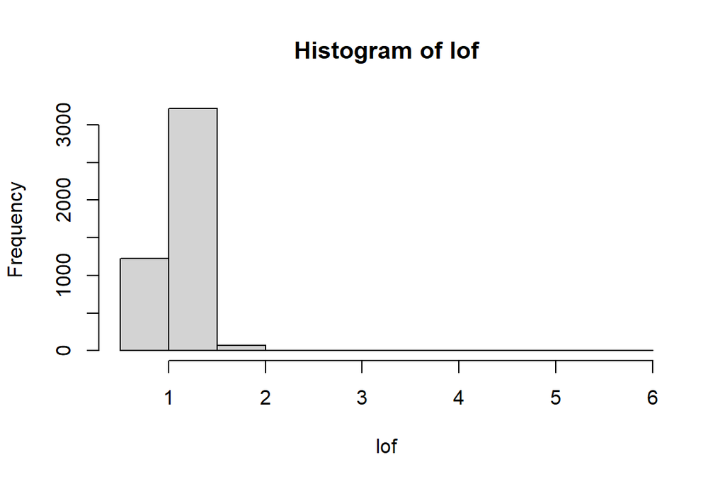

```r
hist(lof)
```

It could be useful to plot also the sorted LOF scores:

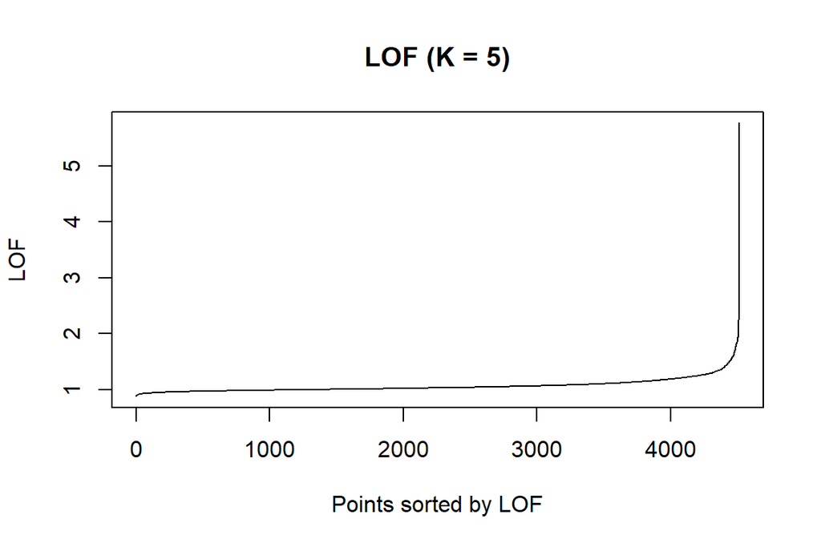

```r
plot(sort(lof), type = "l",  main = "LOF (K = 5)",
  xlab = "Points sorted by LOF", ylab = "LOF")
```

Looks like outliers start around a LOF value of 2.0.

Let’s show the indexes for 5 most outlying observations:

```r
lof_with_names = lof
names(lof_with_names) <- 1:nrow(data_dummy)
sort(lof_with_names, decreasing = TRUE)[1:5]
```

```
##     4511     2967     3413     3542      856
## 5.766932 2.622858 2.299728 2.248045 2.058318
```

Indexes of the outliers with a lof score above 2.0:

```r
outliers_lof <- which(lof > 2.0)
```

Number of detected outliers:

```r
length(outliers_lof)
```

```
## [1] 7
```

```r
outliers_lof
```

```
## [1]  856 2888 2967 3047 3413 3542 4511
```

We will simply remove the found outliers (found with lof) from the dataset (taking into account that algorithms such as k-means are very sensitive to outliers):

```r
data_dummy = data_dummy[-outliers_lof,]
```

Let’s now check again the dimensions:

```r
dim(data_dummy)
```

```
## [1] 4507   54
```

The outliers have been correctly removed!

### 1.2.4 PCA

A further step to gain more insights about the dataset could be to perform dimensionality reduction by applying factor analysis methods.

Since we don’t have specific groups of variables, we’ll perform a PCA by using the continuous features:

- our purpose is to find some useful relationships between variables and individuals, with respect to the class
- we will exploit these insights to perform classification

We’ll use *FactoMineR* for performing the PCA:

```r
str(data_dummy)
```

```
## 'data.frame':    4507 obs. of  54 variables:
##  $ ID                   : int  1 2 3 4 5 6 7 8 9 10 ...
##  $ age                  : int  30 33 35 30 59 35 36 39 41 43 ...
##  $ balance              : int  1787 4789 1350 1476 0 747 307 147 221 -88 ...
##  $ duration             : int  79 220 185 199 226 141 341 151 57 313 ...
##  $ campaign             : int  1 1 1 4 1 2 1 2 2 1 ...
##  $ previous             : int  0 4 1 0 0 3 2 0 0 2 ...
##  $ y                    : num  0 0 0 0 0 0 0 0 0 0 ...
##  $ poutcome_failure     : int  0 1 1 0 0 1 0 0 0 1 ...
##  $ poutcome_success     : int  0 0 0 0 0 0 0 0 0 0 ...
##  $ poutcome_unknown     : int  1 0 0 1 1 0 1 1 1 0 ...
##  $ job_admin.           : int  0 0 0 0 0 0 0 0 0 0 ...
##  $ job_blue-collar      : int  0 0 0 0 1 0 0 0 0 0 ...
##  $ job_entrepreneur     : int  0 0 0 0 0 0 0 0 1 0 ...
##  $ job_housemaid        : int  0 0 0 0 0 0 0 0 0 0 ...
```

[output cut: 40 more lines]

```r
?PCA
```

```
## starting httpd help server ... done
```

```r
data_ = data_dummy[2:18]
res.pca = PCA(data_, scale.unit=TRUE, quali.sup = 7, ncp=5, graph=F)
```

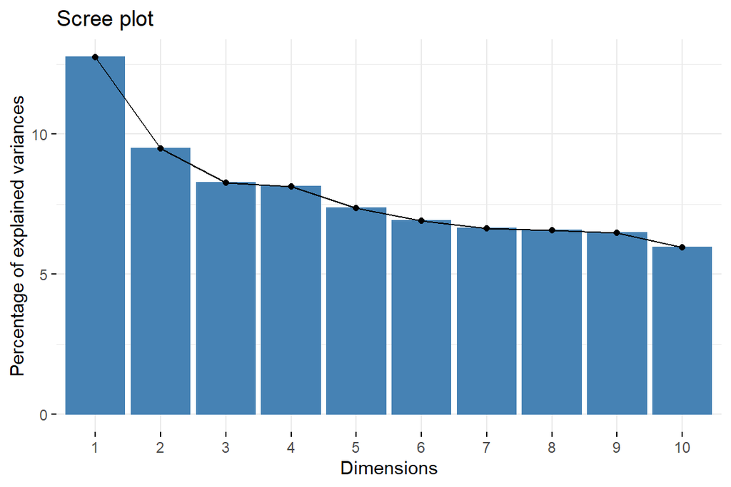

```r
fviz_eig(res.pca)
```

```r
?fviz_pca_ind
```

Individuals plot:

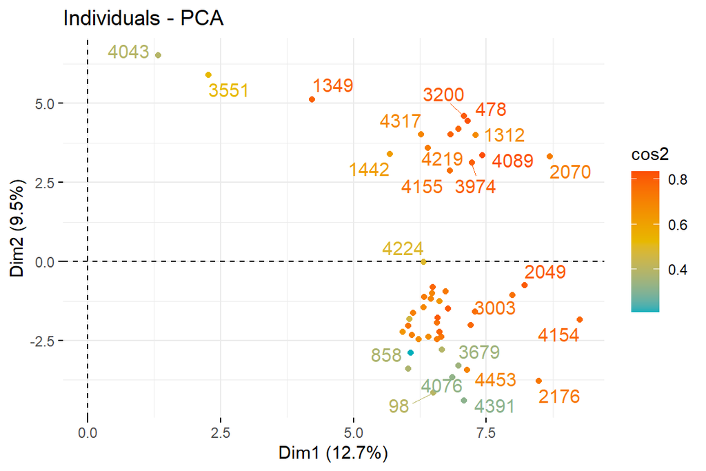

```r
fviz_pca_ind(res.pca,
             col.ind = "cos2", # Color by the quality of representation
             select.ind = list(contrib =50),
             gradient.cols = c("#00AFBB", "#E7B800", "#FC4E07"),
             repel = TRUE     # Avoid text overlapping
             )
```

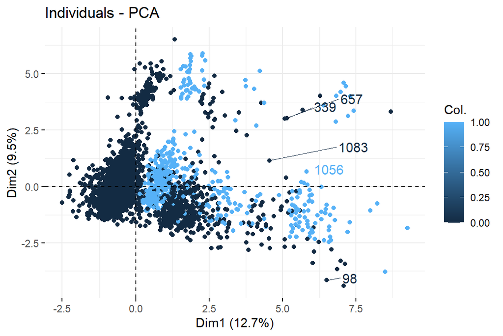

```r
fviz_pca_ind(res.pca,
             col.ind = data_dummy$y,
             repel = TRUE     # Avoid text overlapping
             )
```

We can see that the 1st factorial plane separates pretty well the individuals according to the 2 classes.

We are more interested in visualizing the variables plot:

```r
?fviz_pca_var
```

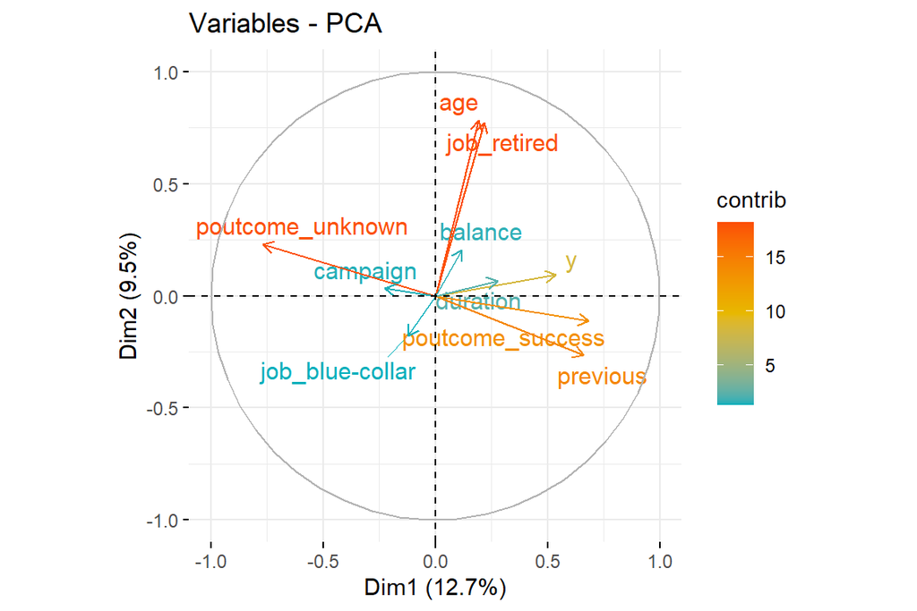

```r
fviz_pca_var(res.pca,
             col.var = "contrib", # Color by contributions to the PC
             gradient.cols = c("#00AFBB", "#E7B800", "#FC4E07"),
             repel = TRUE ,   # Avoid text overlapping
             select.var = list(contrib=10)
             )
```

We may perform the plot on the 3rd and 4th PCs:

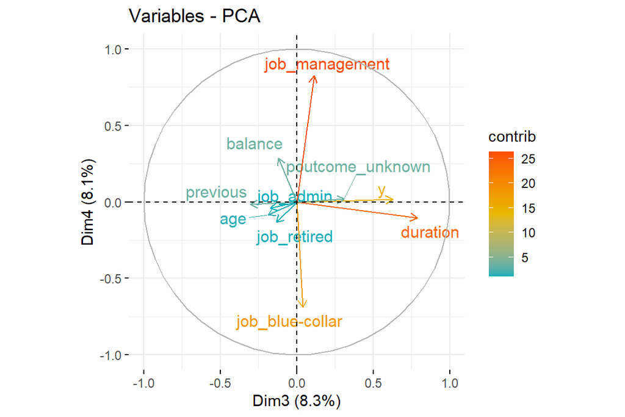

```r
fviz_pca_var(res.pca,
             axes = c(3,4),
             col.var = "contrib", # Color by contributions to the PC
             gradient.cols = c("#00AFBB", "#E7B800", "#FC4E07"),
             repel = TRUE,     # Avoid text overlapping
             select.var = list(contrib=10)
             )
```

Again, we see the same correlation among ‘age’ and ‘job_retired’. There is also a positive correlation between the target variable ‘y’ and the variable ‘duration’.

Biplot:

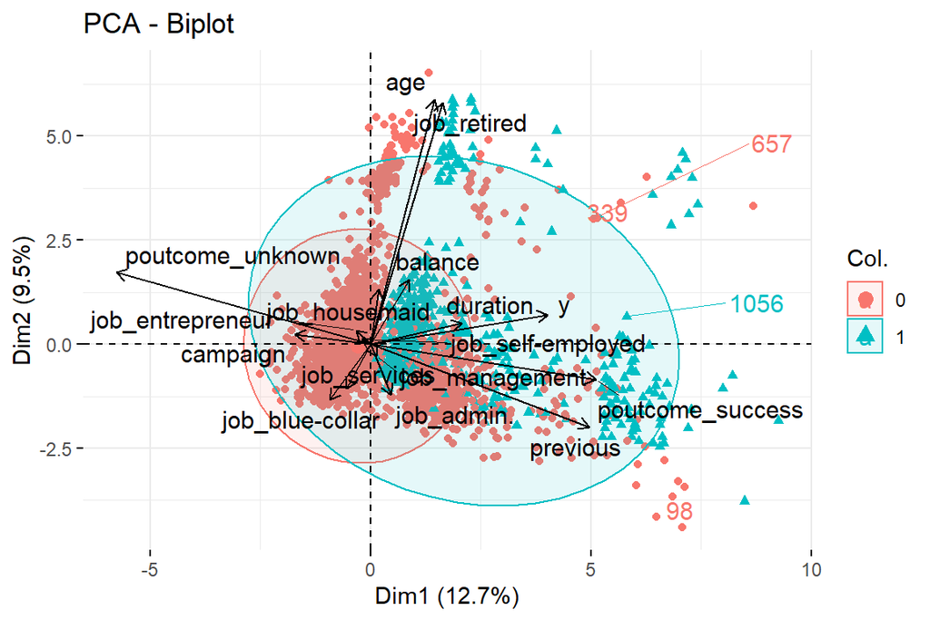

```r
data_dummy[,"y"] = as.factor(data_dummy[,"y"])
fviz_pca_biplot(res.pca, repel = TRUE,
                axes = c(1,2),
                col.var = "black", # Variables color
                col.ind = data_dummy$y,
                addEllipses = TRUE
                )
```

The biplot summarizes all what we’ve said before.

Since PCA tries to maximize the variance inside the dataset, it is not so useful for a classification task. Our next step is therefore to try to apply an LDA, just for visualizing better the data, specifically, we tried to understand if the two classes could be linearly separated:

```r
library(MASS)
(model <- lda(y~., data = data_dummy))
```

```
## Call:
## lda(y ~ ., data = data_dummy)
##
## Prior probabilities of groups:
##         0         1
## 0.8848458 0.1151542
##
## Group means:
##         ID      age  balance duration campaign  previous poutcome_failure
## 0 2260.277 40.98195 1378.594 225.2931 2.842528 0.4724173        0.1068205
## 1 2244.480 42.49518 1571.881 544.8054 2.263969 1.0944123        0.1213873
##   poutcome_success poutcome_unknown job_admin. `job_blue-collar`
## 0        0.0115346        0.8816449  0.1053159         0.2191575
## 1        0.1599229        0.7186898  0.1117534         0.1310212
##   job_entrepreneur job_housemaid job_management job_retired `job_self-employed`
## 0       0.03811434    0.02457372      0.2101304  0.04388164          0.04062187
## 1       0.02697495    0.02697495      0.2524085  0.10404624          0.03853565
##   job_services job_student job_technician job_unemployed job_unknown
## 0   0.09478435  0.01604814      0.1715145     0.02808425  0.00777332
## 1   0.07321773  0.03660886      0.1599229     0.02504817  0.01348748
##   marital_divorced marital_married marital_single education_primary
## 0        0.1128385       0.6296389      0.2575226         0.1527081
## 1        0.1464355       0.5317919      0.3217726         0.1213873
##   education_secondary education_tertiary education_unknown default_no
## 0           0.5157974          0.2893681        0.04212638  0.9839519
## 1           0.4720617          0.3699422        0.03660886  0.9826590
##   default_yes housing_no housing_yes   loan_no   loan_yes  month_apr month_aug
## 0  0.01604814  0.4152457   0.5847543 0.8385155 0.16148445 0.05942828 0.1384152
## 1  0.01734104  0.5780347   0.4219653 0.9171484 0.08285164 0.10789981 0.1522158
##     month_dec  month_feb  month_jan month_jul month_jun   month_mar month_may
## 0 0.002758275 0.04613842 0.03259779 0.1609829 0.1191073 0.007021063 0.3264794
## 1 0.017341040 0.07321773 0.03082852 0.1175337 0.1021195 0.040462428 0.1791908
##    month_nov  month_oct   month_sep `pdays_Never contacted`
## 0 0.08776329 0.01053159 0.008776329               0.8417753
## 1 0.07514451 0.07129094 0.032755299               0.6454721
##   `pdays_Under 3months` `pdays_Under 6months` `pdays_Under 9months`
## 0            0.01178536            0.04914744            0.03610832
## 1            0.04624277            0.14065511            0.08670520
##   `pdays_Under 1yr` `pdays_Under 1.5yrs` `pdays_Over 1.5yrs`
## 0        0.04689067           0.01328987         0.001003009
```

[output cut: 42 more lines]

```
## month_jan               -2.729110e-01
## month_jul               -1.421914e-01
## month_jun               -4.978486e-04
## month_mar                1.740769e+00
## month_may               -2.480090e-01
## month_nov               -2.232277e-01
## month_oct                1.771882e+00
## month_sep                7.539028e-01
## `pdays_Never contacted` -3.179020e-01
## `pdays_Under 3months`    4.621018e-01
## `pdays_Under 6months`    3.823838e-01
## `pdays_Under 9months`    1.593788e-01
## `pdays_Under 1yr`       -8.500842e-02
## `pdays_Under 1.5yrs`     8.113097e-01
## `pdays_Over 1.5yrs`      1.694139e+00
```

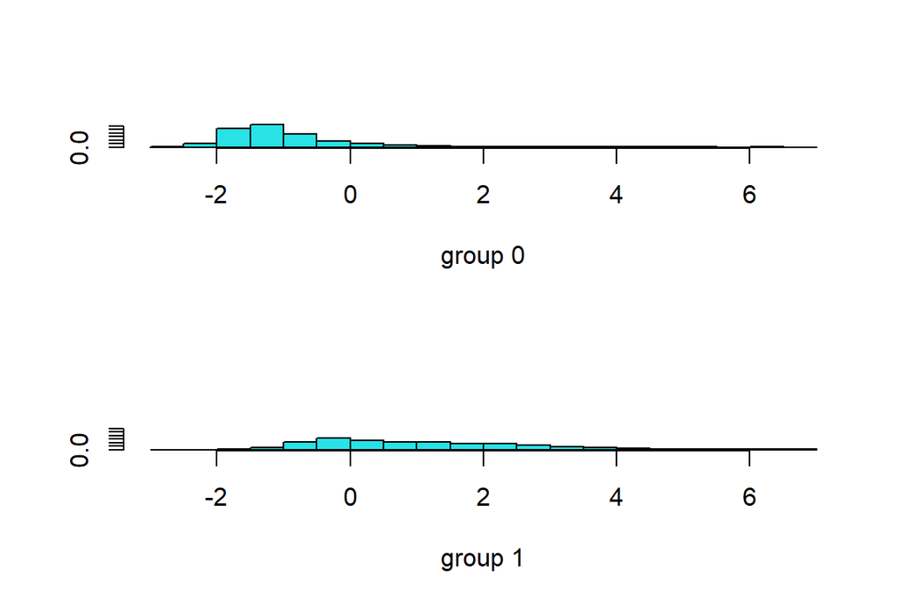

```r
plot(model)
```

As we can see, the new dimension created by LDA is not much able to separate the points into 2 clusters. We cann see a lot of overlapping around the value of 0 of the axes.

### 1.2.5 Splitting

We’ ll split the dataset into training and validation:

- 80% of the original data will be used for training
- the reaming 20% will be used to evaluate the final performance of the classifier

An important remark is that the considered dataset is highly unbalanced: most of the customers belong to the ‘no’ values of the target variable. For that reason, and in order to have a fair evaluation of our algorithms we’ll perform a stratified splitting:

- we’ll select 80% among all the clients belonging to the positive class for training and 20% for testing
- we’ll select 80% among all the clients belonging to the negative class for training and 20% for testing

In this way we’ll have the same distribution of observations inside the two classes in both the training and test set.

```r
data_dummy <- data_dummy %>% relocate(y, .after = "pdays_Over 1.5yrs")
```

```r
str(data_dummy)
```

```
## 'data.frame':    4507 obs. of  54 variables:
##  $ ID                   : int  1 2 3 4 5 6 7 8 9 10 ...
##  $ age                  : int  30 33 35 30 59 35 36 39 41 43 ...
##  $ balance              : int  1787 4789 1350 1476 0 747 307 147 221 -88 ...
##  $ duration             : int  79 220 185 199 226 141 341 151 57 313 ...
##  $ campaign             : int  1 1 1 4 1 2 1 2 2 1 ...
##  $ previous             : int  0 4 1 0 0 3 2 0 0 2 ...
##  $ poutcome_failure     : int  0 1 1 0 0 1 0 0 0 1 ...
##  $ poutcome_success     : int  0 0 0 0 0 0 0 0 0 0 ...
##  $ poutcome_unknown     : int  1 0 0 1 1 0 1 1 1 0 ...
##  $ job_admin.           : int  0 0 0 0 0 0 0 0 0 0 ...
##  $ job_blue-collar      : int  0 0 0 0 1 0 0 0 0 0 ...
##  $ job_entrepreneur     : int  0 0 0 0 0 0 0 0 1 0 ...
##  $ job_housemaid        : int  0 0 0 0 0 0 0 0 0 0 ...
##  $ job_management       : int  0 0 1 1 0 1 0 0 0 0 ...
```

[output cut: 40 more lines]

```r
set.seed(123)
#Training & Test Datasets
deposit_yes <- data_dummy[which(data_dummy$y == 1), ]  # all yes's of target class
deposit_no <- data_dummy[which(data_dummy$y ==  0), ]  # all no's of target class

deposit_yes_training_rows <- sample(1:nrow(deposit_yes), 0.8*nrow(deposit_yes))  #randomly choosing 80% observations of yes class
deposit_no_training_rows <- sample(1:nrow(deposit_no), 0.8*nrow(deposit_no))  #randomly choosing 80% observations of no class
training_yes <- deposit_yes[deposit_yes_training_rows, ]
training_no <- deposit_no[deposit_no_training_rows, ]
trainingData <- rbind(training_yes, training_no)  #combining chosen observations
glimpse(trainingData)
```

```
## Rows: 3,605
## Columns: 54
## $ ID                      <int> 3667, 4090, 1502, 1699, 1021, 2584, 1929, 2050~
## $ age                     <int> 32, 32, 46, 31, 42, 52, 22, 59, 37, 52, 42, 55~
## $ balance                 <int> 38, -53, 57, 3283, 994, 2557, 3472, 4198, 1315~
## $ duration                <int> 744, 648, 796, 258, 149, 134, 332, 309, 224, 2~
## $ campaign                <int> 1, 1, 1, 1, 1, 5, 1, 1, 1, 1, 1, 4, 1, 6, 2, 1~
## $ previous                <int> 0, 1, 0, 1, 5, 2, 3, 10, 0, 1, 1, 0, 0, 0, 0, ~
## $ poutcome_failure        <int> 0, 0, 0, 1, 1, 0, 1, 0, 0, 1, 0, 0, 0, 0, 0, 1~
## $ poutcome_success        <int> 0, 0, 0, 0, 0, 1, 0, 1, 0, 0, 1, 0, 0, 0, 0, 0~
## $ poutcome_unknown        <int> 1, 1, 1, 0, 0, 0, 0, 0, 1, 0, 0, 1, 1, 1, 1, 0~
## $ job_admin.              <int> 0, 0, 0, 0, 0, 0, 0, 0, 0, 0, 0, 0, 0, 0, 0, 0~
## $ `job_blue-collar`       <int> 0, 1, 0, 0, 0, 0, 0, 0, 0, 1, 0, 0, 0, 0, 0, 0~
## $ job_entrepreneur        <int> 0, 0, 0, 0, 0, 0, 0, 0, 0, 0, 0, 0, 0, 0, 0, 0~
## $ job_housemaid           <int> 0, 0, 0, 0, 0, 0, 0, 0, 0, 0, 0, 0, 0, 1, 0, 0~
```

[output cut: 41 more lines]

```r
table(trainingData$y)
```

```
##
##    0    1
## 3190  415
```

```r
# Create Test Data
test_yes <- deposit_yes[-deposit_yes_training_rows, ]
test_no <- deposit_no[-deposit_no_training_rows, ]
testData <- rbind(test_yes, test_no)  #combining chosen observations
glimpse(testData)
```

```
## Rows: 902
## Columns: 54
## $ ID                      <int> 14, 51, 93, 109, 111, 115, 299, 300, 329, 335,~
## $ age                     <int> 20, 45, 27, 56, 21, 25, 38, 32, 35, 30, 55, 60~
## $ balance                 <int> 502, 844, -195, 3391, 2488, 331, 593, 759, 978~
## $ duration                <int> 261, 1018, 391, 243, 258, 170, 1484, 317, 1370~
## $ campaign                <int> 1, 3, 1, 1, 6, 4, 24, 5, 3, 4, 2, 1, 1, 1, 1, ~
## $ previous                <int> 0, 0, 0, 0, 3, 0, 0, 0, 3, 0, 2, 0, 0, 0, 2, 0~
## $ poutcome_failure        <int> 0, 0, 0, 0, 0, 0, 0, 0, 0, 0, 0, 0, 0, 0, 0, 0~
## $ poutcome_success        <int> 0, 0, 0, 0, 1, 0, 0, 0, 1, 0, 1, 0, 0, 0, 1, 0~
## $ poutcome_unknown        <int> 1, 1, 1, 1, 0, 1, 1, 1, 0, 1, 0, 1, 1, 1, 0, 1~
## $ job_admin.              <int> 0, 0, 0, 0, 0, 0, 0, 0, 0, 0, 0, 0, 0, 1, 1, 0~
## $ `job_blue-collar`       <int> 0, 1, 0, 0, 0, 0, 0, 1, 0, 0, 0, 0, 0, 0, 0, 0~
## $ job_entrepreneur        <int> 0, 0, 0, 0, 0, 0, 1, 0, 0, 0, 0, 0, 0, 0, 0, 0~
## $ job_housemaid           <int> 0, 0, 0, 0, 0, 0, 0, 0, 0, 0, 0, 0, 0, 0, 0, 0~
```

[output cut: 41 more lines]

```r
table(testData$y)
```

```
##
##   0   1
## 798 104
```

We can save the training and test dataset, so that we can direclty use them in the main algorithms:

```r
#save(trainingData, testData, trainingData_scaled, testData_scaled, file = "data.RData")
save(trainingData, testData, file = "data.RData")
```